# W3cubDocs

## Examples using `matplotlib.pyplot.scatter`

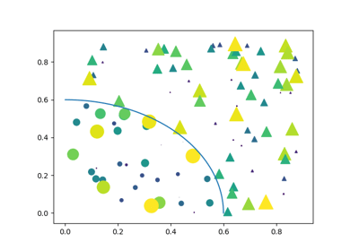

[Scatter Masked](https://matplotlib.org/3.1.1/gallery/lines_bars_and_markers/scatter_masked.html#sphx-glr-gallery-lines-bars-and-markers-scatter-masked-py)

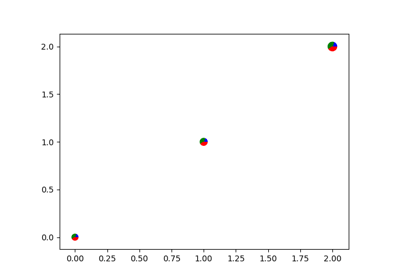

[Scatter plot with pie chart markers](https://matplotlib.org/3.1.1/gallery/lines_bars_and_markers/scatter_piecharts.html#sphx-glr-gallery-lines-bars-and-markers-scatter-piecharts-py)

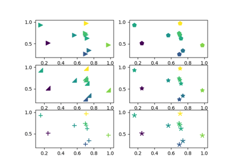

[Scatter Star Poly](https://matplotlib.org/3.1.1/gallery/lines_bars_and_markers/scatter_star_poly.html#sphx-glr-gallery-lines-bars-and-markers-scatter-star-poly-py)

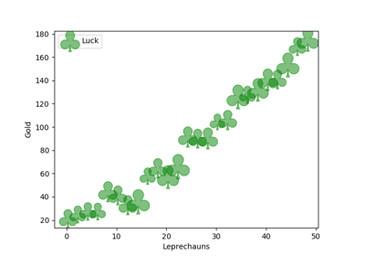

[Scatter Symbol](https://matplotlib.org/3.1.1/gallery/lines_bars_and_markers/scatter_symbol.html#sphx-glr-gallery-lines-bars-and-markers-scatter-symbol-py)

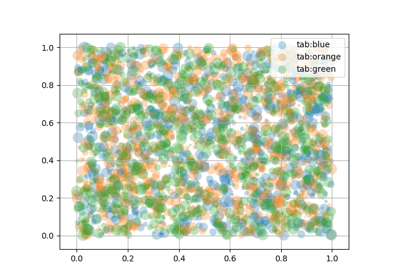

[Scatter plots with a legend](https://matplotlib.org/3.1.1/gallery/lines_bars_and_markers/scatter_with_legend.html#sphx-glr-gallery-lines-bars-and-markers-scatter-with-legend-py)

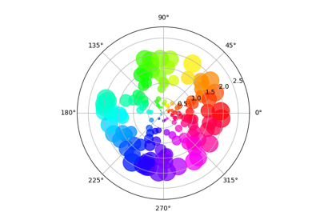

[Scatter plot on polar axis](https://matplotlib.org/3.1.1/gallery/pie_and_polar_charts/polar_scatter.html#sphx-glr-gallery-pie-and-polar-charts-polar-scatter-py)

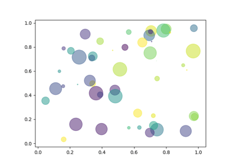

[Scatter plot](https://matplotlib.org/3.1.1/gallery/shapes_and_collections/scatter.html#sphx-glr-gallery-shapes-and-collections-scatter-py)

[figure not shown]

[Hyperlinks](https://matplotlib.org/3.1.1/gallery/misc/hyperlinks_sgskip.html#sphx-glr-gallery-misc-hyperlinks-sgskip-py)

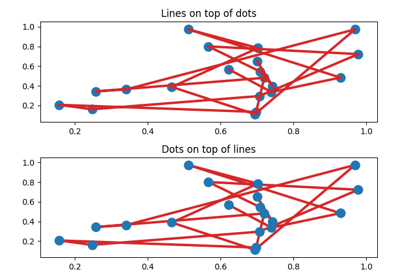

[Zorder Demo](https://matplotlib.org/3.1.1/gallery/misc/zorder_demo.html#sphx-glr-gallery-misc-zorder-demo-py)

[Pyplot tutorial](https://matplotlib.org/3.1.1/tutorials/introductory/pyplot.html#sphx-glr-tutorials-introductory-pyplot-py)